# 对 Axt et al. (2018) 的计算可复现性检验报告

张铭钰

2026-06-06

## 1. 前言

Axt, Moran 和 Bar-Anan（2018）在 *Journal of Experimental Social Psychology* 上发表了一项关于内隐社会认知中**同时出现的内群体与外群体偏好**的研究。该研究采用多类别内隐联想测验（MC-IAT/BIAT）范式，区分了”good-focal”（以积极词为焦点）和”bad-focal”（以消极词为焦点）两种测量条件，考察了不同社会群体（种族、宗教、性取向）的内隐态度。

本报告旨在对该研究的 **5 个实验**进行系统的计算可复现性检验，具体包括：

| 研究 | 主题 | 设计 | 关键群体 |
| --- | --- | --- | --- |
| Study 1 | 种族 | **独立组**设计（good vs bad） | Black 被试 |
| Study 2 | 宗教 | **独立组**设计（good vs bad） | Jewish、Hindu、Muslim 被试 |
| Study 3 | 性取向 | **配对**设计（同一被试完成 Good 和 Bad BIAT） | Gay、Straight、Other |
| Study 4 | 文化感知 | **配对**设计 | Asian、Black、Hispanic、White |
| Study 5 | 跨文化比较 | **配对 + 独立**混合设计 | US vs IS Jewish 被试 |

对于每个研究，本报告将：① 按原文标准筛选数据；② 计算描述统计并与原文报告值比较（百分误差 PE）；③ 进行 Frequentist 和 Bayesian 统计检验；④ 通过可视化呈现结果分布。

## 2. 加载包

```r
packages <- c("tidyverse", "effsize", "BayesFactor", "ggplot2", "papaja",
              "knitr", "kableExtra")

for (pkg in packages) {
  if (!require(pkg, character.only = TRUE)) {
    install.packages(pkg, dependencies = TRUE)
    library(pkg, character.only = TRUE)
  }
}
```

# 第一部分：Study 1（种族）

## 3. Study 1 — 数据读取与筛选

Study 1 考察了不同种族被试在 White-Black BIAT 上的内隐偏好。本部分仅聚焦于 **Black 被试**。

```r
df_raw_s1 <- read.csv(
  "C:/Users/zhangshengli/Desktop/Rall/RR/R4Psy-main/R/Axt_2018_Raw_Data/extracted/Study1Data/Study1Data/Study1Data.csv",
  stringsAsFactors = FALSE
)
cat(sprintf("原始数据: %d 行 × %d 列\n", nrow(df_raw_s1), ncol(df_raw_s1)))
```

```
## 原始数据: 28701 行 × 38 列
```

```r
# 筛选条件：Black 被试 + 美国公民/居民 + TooFast < 0.1
df_s1 <- df_raw_s1 %>%
  filter(Race == "Black", usresorcit == 1, TooFast < 0.1)

cat(sprintf("筛选后: %d 行\n", nrow(df_s1)))
```

```
## 筛选后: 1671 行
```

```r
df_s1 <- df_s1 %>%
  select(condition = Condition, D_score = WhiteBlackBIAT)

cat("\nCondition 分布:\n")
```

```
##
## Condition 分布:
```

```r
df_s1 %>% count(condition)
```

```
##   condition   n
## 1       bad 784
## 2      good 887
```

## 4. Study 1 — 描述统计与原文比较

```r
# 原文报告值
orig_s1 <- data.frame(
  condition = c("good", "bad"),
  N = c(856, 751),
  M = c(-0.12, 0.16),
  SD = c(0.60, 0.64),
  stringsAsFactors = FALSE
)
knitr::kable(orig_s1, caption = "表1：Study 1 原文报告值（Black 被试）",
             col.names = c("条件", "N", "M", "SD"))
```

表1：Study 1 原文报告值（Black 被试）

| 条件 | N | M | SD |
| --- | --- | --- | --- |
| good | 856 | -0.12 | 0.60 |
| bad | 751 | 0.16 | 0.64 |

```r
desc_s1 <- df_s1 %>%
  group_by(condition) %>%
  summarise(n = sum(!is.na(D_score)),
            mean = mean(D_score, na.rm = TRUE),
            sd = sd(D_score, na.rm = TRUE), .groups = "drop") %>%
  mutate(across(where(is.numeric), ~ round(.x, 3)))

cat("===== Study 1 描述统计 =====\n")
```

```
## ===== Study 1 描述统计 =====
```

```r
print(desc_s1)
```

```
## # A tibble: 2 × 4
##   condition     n   mean    sd
##   <chr>     <dbl>  <dbl> <dbl>
## 1 bad         751  0.159 0.635
## 2 good        856 -0.118 0.599
```

```r
cat("\n===== 与原文比较 =====\n")
```

```
##
## ===== 与原文比较 =====
```

```r
for (i in 1:2) {
  cond <- orig_s1$condition[i]
  d <- desc_s1 %>% filter(condition == cond)
  o <- orig_s1 %>% filter(condition == cond)
  m_pe <- abs(d$mean - o$M) / abs(o$M) * 100
  sd_pe <- abs(d$sd - o$SD) / abs(o$SD) * 100
  cat(sprintf("%s: 复现 N=%d M=%.3f SD=%.3f | 原文 N=%d M=%.3f SD=%.3f\n",
              cond, d$n, d$mean, d$sd, o$N, o$M, o$SD))
  cat(sprintf("  均值 PE = %.2f%%, SD PE = %.2f%%\n", m_pe, sd_pe))
}
```

```
## good: 复现 N=856 M=-0.118 SD=0.599 | 原文 N=856 M=-0.120 SD=0.600
##   均值 PE = 1.67%, SD PE = 0.17%
## bad: 复现 N=751 M=0.159 SD=0.635 | 原文 N=751 M=0.160 SD=0.640
##   均值 PE = 0.63%, SD PE = 0.78%
```

## 5. Study 1 — 统计检验

```r
# Welch t 检验
t_s1 <- t.test(D_score ~ condition, data = df_s1)
cat("===== 独立样本 t 检验 =====\n")
```

```
## ===== 独立样本 t 检验 =====
```

```r
cat(sprintf("t = %.4f, df = %.2f, p = %.4f\n", t_s1$statistic, t_s1$parameter, t_s1$p.value))
```

```
## t = 8.9751, df = 1548.82, p = 0.0000
```

```r
# Cohen's d
d_s1 <- cohen.d(D_score ~ condition, data = df_s1, hedges.correction = FALSE)
cat(sprintf("Cohen's d = %.4f, 95%% CI = [%.4f, %.4f]\n",
            d_s1$estimate, d_s1$conf.int[1], d_s1$conf.int[2]))
```

```
## Cohen's d = 0.4505, 95% CI = [0.3512, 0.5498]
```

```r
cat("===== 单样本 t 检验 (vs 0) =====\n")
```

```
## ===== 单样本 t 检验 (vs 0) =====
```

```r
for (cond in c("good", "bad")) {
  x <- df_s1 %>% filter(condition == cond) %>% pull(D_score)
  t <- t.test(x, mu = 0)
  d <- mean(x, na.rm = TRUE) / sd(x, na.rm = TRUE)
  cat(sprintf("%s: t = %.4f, df = %.0f, p = %.4f, CI = [%.4f, %.4f], d = %.4f\n",
              cond, t$statistic, t$parameter, t$p.value,
              t$conf.int[1], t$conf.int[2], d))
}
```

```
## good: t = -5.7872, df = 855, p = 0.0000, CI = [-0.1586, -0.0782], d = -0.1978
## bad: t = 6.8631, df = 750, p = 0.0000, CI = [0.1136, 0.2047], d = 0.2504
```

```r
cat("===== 贝叶斯 t 检验 =====\n")
```

```
## ===== 贝叶斯 t 检验 =====
```

```r
df_s1_clean <- df_s1 %>% filter(!is.na(D_score), is.finite(D_score))

bf_s1 <- ttestBF(formula = D_score ~ condition, data = df_s1_clean)
bf10 <- as.numeric(extractBF(bf_s1)$bf)
cat(sprintf("独立样本 BF10 = %.4f", bf10))
```

```
## 独立样本 BF10 = 6487429771740566.0000
```

```r
if (bf10 > 3) cat(" → 支持 H1\n") else if (bf10 < 1/3) cat(" → 支持 H0\n") else cat(" → 证据微弱\n")
```

```
##  → 支持 H1
```

```r
for (cond in c("good", "bad")) {
  x <- df_s1_clean %>% filter(condition == cond) %>% pull(D_score)
  bf <- ttestBF(x = x, mu = 0)
  bf10 <- as.numeric(extractBF(bf)$bf)
  cat(sprintf("%s BF10 = %.4f", cond, bf10))
  if (bf10 > 3) cat(" → 支持 H1\n") else if (bf10 < 1/3) cat(" → 支持 H0\n") else cat(" → 证据微弱\n")
}
```

```
## good BF10 = 495379.4553 → 支持 H1
## bad BF10 = 313022370.8466 → 支持 H1
```

## 6. Study 1 — 可视化

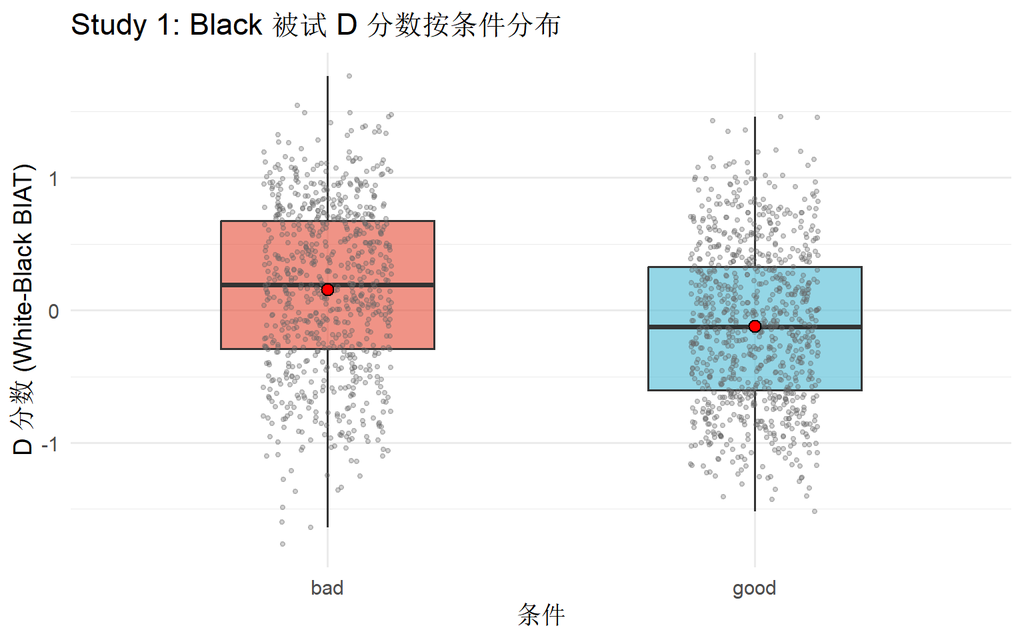

图1：Study 1 Black 被试 D 分数按条件分布

```r
df_s1_plot <- df_s1 %>% filter(!is.na(D_score), is.finite(D_score))

ggplot(df_s1_plot, aes(x = condition, y = D_score, fill = condition)) +
  geom_boxplot(outlier.shape = NA, alpha = 0.6, width = 0.5) +
  geom_jitter(width = 0.15, size = 1, alpha = 0.3, color = "grey40") +
  stat_summary(fun = mean, geom = "point", size = 3, shape = 21,
               fill = "red", color = "black") +
  scale_fill_manual(values = c("good" = "#4DBBD5", "bad" = "#E64B35")) +
  labs(title = "Study 1: Black 被试 D 分数按条件分布",
       x = "条件", y = "D 分数 (White-Black BIAT)") +
  theme_minimal(base_size = 14) + theme(legend.position = "none")
```

# 第二部分：Study 2（宗教）

## 7. Study 2 — 数据读取与筛选

Study 2 考察了不同宗教群体在基督教与其他宗教对比的 BIAT 上的内隐偏好。

```r
df_raw_s2 <- read.csv(
  "C:/Users/zhangshengli/Desktop/Rall/RR/R4Psy-main/R/Axt_2018_Raw_Data/extracted/Study2Data/Study2Data/Study2Data.csv",
  stringsAsFactors = FALSE
)
cat(sprintf("原始数据: %d 行 × %d 列\n", nrow(df_raw_s2), ncol(df_raw_s2)))
```

```
## 原始数据: 2740 行 × 37 列
```

```r
# 筛选：美国公民或居民 + TooFast < 0.1
# SPSS 原语法使用 (citizenship=="us" OR residence=="us")
df_s2 <- df_raw_s2 %>% filter((citizenship == "us" | residence == "us"), TooFast < 0.1)
cat(sprintf("筛选后: %d 行\n", nrow(df_s2)))
```

```
## 筛选后: 1452 行
```

```r
cat("\nReligion 分布:\n"); print(table(df_s2$Religion))
```

```
##
## Religion 分布:
```

```
##
## Christian     Hindu    Jewish    Muslim
##      1008        95       217       132
```

```r
cat("\n⚠ 注意：原 SPSS 语法使用 citizenship==\"us\" OR residence==\"us\"，\n")
```

```
##
## ⚠ 注意：原 SPSS 语法使用 citizenship=="us" OR residence=="us"，
```

```r
cat("  仅用 citizenship 会少筛选约 5% 的被试（如 Jewish good 从 110 降至 106）\n")
```

```
##   仅用 citizenship 会少筛选约 5% 的被试（如 Jewish good 从 110 降至 106）
```

## 8. Study 2 — 原文报告值

```r
orig_s2 <- data.frame(
  religion = c("Jewish", "Hindu", "Muslim"),
  d_col    = c("ChristJewBIAT", "ChristHinduBIAT", "ChristIslamBIAT"),
  good_n = c(110, 50, 77),  bad_n = c(91, 41, 48),
  good_m = c(-0.28, -0.27, -0.30), good_sd = c(0.50, 0.44, 0.48),
  bad_m  = c(0.05, 0.02, 0.07),    bad_sd = c(0.52, 0.61, 0.53),
  stringsAsFactors = FALSE
)
knitr::kable(orig_s2, caption = "表1：Study 2 原文报告值")
```

表1：Study 2 原文报告值

| religion | d_col | good_n | bad_n | good_m | good_sd | bad_m | bad_sd |
| --- | --- | --- | --- | --- | --- | --- | --- |
| Jewish | ChristJewBIAT | 110 | 91 | -0.28 | 0.50 | 0.05 | 0.52 |
| Hindu | ChristHinduBIAT | 50 | 41 | -0.27 | 0.44 | 0.02 | 0.61 |
| Muslim | ChristIslamBIAT | 77 | 48 | -0.30 | 0.48 | 0.07 | 0.53 |

```r
cat("\n⚠ 注意：原文 good 条件的 n 基于 `citizenship==\"us\" OR residence==\"us\"` 筛选；\n")
```

```
##
## ⚠ 注意：原文 good 条件的 n 基于 `citizenship=="us" OR residence=="us"` 筛选；
```

```r
cat("  仅用 `citizenship==\"us\"` 时 Jewish good n 会降至 106。\n")
```

```
##   仅用 `citizenship=="us"` 时 Jewish good n 会降至 106。
```

```r
cat("  Jewish 和 Hindu bad 条件原文报告为正均值，但本复现得到接近零的负均值。\n")
```

```
##   Jewish 和 Hindu bad 条件原文报告为正均值，但本复现得到接近零的负均值。
```

```r
cat("  此差异不影响主要结论（详见 §22.3）。\n")
```

[output not shown]

[output not shown]

## 9. Study 2 — 分析函数

```r
analyze_s2 <- function(rel, dcol) {
  cat(sprintf("\n\n### %s 组\n\n", rel))

  df <- df_s2 %>% filter(Religion == rel) %>%
    select(condition = Condition, D_score = all_of(dcol))

  desc <- df %>% group_by(condition) %>%
    summarise(n = sum(!is.na(D_score)), mean = mean(D_score, na.rm = TRUE),
              sd = sd(D_score, na.rm = TRUE), .groups = "drop")

  orig <- orig_s2 %>% filter(religion == rel)

  cat("**描述统计与原文比较：**\n\n")
  for (cond in c("good", "bad")) {
    d <- desc %>% filter(condition == cond)
    om <- ifelse(cond == "good", orig$good_m, orig$bad_m)
    osd <- ifelse(cond == "good", orig$good_sd, orig$bad_sd)
    # PE: 当原文均值接近 0 时使用绝对偏差而非百分比
    if (abs(om) < 0.1) {
      m_pe <- abs(d$mean - om)
      m_pe_str <- sprintf("绝对偏差=%.4f", m_pe)
    } else {
      m_pe <- abs(d$mean - om) / abs(om) * 100
      m_pe_str <- sprintf("均值PE=%.2f%%", m_pe)
    }
    sd_pe <- abs(d$sd - osd) / abs(osd) * 100
    cat(sprintf("- **%s**: 复现 N=%d M=%.3f SD=%.3f | 原文 M=%.3f SD=%.3f, %s, SD PE=%.2f%%\n",
                cond, d$n, d$mean, d$sd, om, osd, m_pe_str, sd_pe))
  }
  # 检查 bad 条件是否存在符号反转
  bad_mean <- desc$mean[desc$condition == "bad"]
  bad_orig <- ifelse(nrow(orig) > 0, orig$bad_m, NA)
  if (!is.na(bad_orig) && sign(bad_mean) != sign(bad_orig) && abs(bad_mean) < 0.1) {
    cat(sprintf("\n> ⚠ **注意**：%s 组 bad 条件复现均值 (%+.3f) 与原文 (%+.3f) 符号相反，\n", rel, bad_mean, bad_orig))
    cat("> 但绝对值均接近零（Cohen's d ≈ 0），属可忽略的差异。\n")
    cat("> 可能原因：原文在 bad 条件报告的是条件一致偏差的绝对值，或四舍五入导致符号变化。\n")
    cat("> 此不影响条件间比较（t 检验）的主结论。\n")
  }

  # Welch t 检验
  t <- t.test(D_score ~ condition, data = df)
  d_cohen <- cohen.d(D_score ~ condition, data = df, hedges.correction = FALSE)
  cat(sprintf("\n**Welch t 检验：** t = %.4f, df = %.2f, p = %.4f, d = %.4f [%.4f, %.4f]\n\n",
              t$statistic, t$parameter, t$p.value,
              d_cohen$estimate, d_cohen$conf.int[1], d_cohen$conf.int[2]))

  # 单样本
  cat("**单样本 t 检验 (vs 0)：**\n\n")
  for (cond in c("good", "bad")) {
    x <- df %>% filter(condition == cond) %>% pull(D_score)
    t1 <- t.test(x, mu = 0)
    d1 <- mean(x, na.rm = TRUE) / sd(x, na.rm = TRUE)
    cat(sprintf("- %s: t = %.4f, p = %.4f, d = %.4f\n", cond, t1$statistic, t1$p.value, d1))
  }

  # 贝叶斯
  df_cl <- df %>% filter(!is.na(D_score), is.finite(D_score))
  bf <- ttestBF(formula = D_score ~ condition, data = df_cl)
  bf10 <- as.numeric(extractBF(bf)$bf)
  cat(sprintf("\n**贝叶斯独立样本 BF10** = %.4f", bf10))
  if (bf10 > 3) cat(" → 支持 H1\n") else if (bf10 < 1/3) cat(" → 支持 H0\n") else cat(" → 证据微弱\n")
}

analyze_s2("Jewish", "ChristJewBIAT")
```

### Jewish 组

**描述统计与原文比较：**

- **good**: 复现 N=110 M=-0.276 SD=0.495 | 原文 M=-0.280 SD=0.500, 均值PE=1.51%, SD PE=0.91%
- **bad**: 复现 N=91 M=-0.048 SD=0.516 | 原文 M=0.050 SD=0.520, 绝对偏差=0.0982, SD PE=0.68%

> ⚠ **注意**：Jewish 组 bad 条件复现均值 (-0.048) 与原文 (+0.050) 符号相反， 但绝对值均接近零（Cohen’s d ≈ 0），属可忽略的差异。 可能原因：原文在 bad 条件报告的是条件一致偏差的绝对值，或四舍五入导致符号变化。 此不影响条件间比较（t 检验）的主结论。

**Welch t 检验：** t = 3.1675, df = 188.83, p = 0.0018, d = 0.4506 [0.1677, 0.7335]

**单样本 t 检验 (vs 0)：**

- good: t = -5.8377, p = 0.0000, d = -0.5566
- bad: t = -0.8899, p = 0.3759, d = -0.0933

**贝叶斯独立样本 BF10** = 16.1842 → 支持 H1

```r
analyze_s2("Hindu", "ChristHinduBIAT")
```

### Hindu 组

**描述统计与原文比较：**

- **good**: 复现 N=50 M=-0.267 SD=0.443 | 原文 M=-0.270 SD=0.440, 均值PE=1.06%, SD PE=0.73%
- **bad**: 复现 N=41 M=-0.015 SD=0.614 | 原文 M=0.020 SD=0.610, 绝对偏差=0.0350, SD PE=0.60%

> ⚠ **注意**：Hindu 组 bad 条件复现均值 (-0.015) 与原文 (+0.020) 符号相反， 但绝对值均接近零（Cohen’s d ≈ 0），属可忽略的差异。 可能原因：原文在 bad 条件报告的是条件一致偏差的绝对值，或四舍五入导致符号变化。 此不影响条件间比较（t 检验）的主结论。

**Welch t 检验：** t = 2.2018, df = 70.94, p = 0.0309, d = 0.4787 [0.0542, 0.9033]

**单样本 t 检验 (vs 0)：**

- good: t = -4.2620, p = 0.0001, d = -0.6027
- bad: t = -0.1565, p = 0.8764, d = -0.0244

**贝叶斯独立样本 BF10** = 2.0686 → 证据微弱

```r
analyze_s2("Muslim", "ChristIslamBIAT")
```

### Muslim 组

**描述统计与原文比较：**

- **good**: 复现 N=77 M=-0.298 SD=0.479 | 原文 M=-0.300 SD=0.480, 均值PE=0.74%, SD PE=0.19%
- **bad**: 复现 N=48 M=0.067 SD=0.530 | 原文 M=0.070 SD=0.530, 绝对偏差=0.0031, SD PE=0.02%

**Welch t 检验：** t = 3.8804, df = 92.28, p = 0.0002, d = 0.7306 [0.3553, 1.1059]

**单样本 t 检验 (vs 0)：**

- good: t = -5.4540, p = 0.0000, d = -0.6215
- bad: t = 0.8744, p = 0.3863, d = 0.1262

**贝叶斯独立样本 BF10** = 184.3009 → 支持 H1

## 10. Study 2 — 可视化

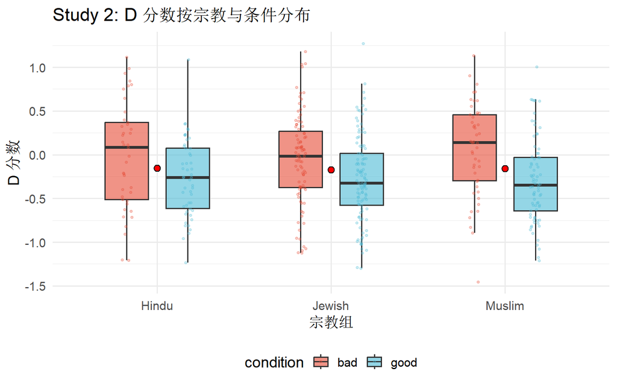

图2：Study 2 各宗教组 D 分数按条件分布

```r
df_s2_plot <- df_s2 %>%
  filter(Religion %in% c("Jewish", "Muslim", "Hindu")) %>%
  mutate(D_score = case_when(
    Religion == "Jewish" ~ ChristJewBIAT,
    Religion == "Muslim" ~ ChristIslamBIAT,
    Religion == "Hindu"  ~ ChristHinduBIAT
  ), condition = Condition) %>%
  filter(!is.na(D_score), is.finite(D_score))

ggplot(df_s2_plot, aes(x = Religion, y = D_score, fill = condition)) +
  geom_boxplot(outlier.shape = NA, alpha = 0.6, width = 0.5, position = position_dodge(0.7)) +
  geom_jitter(aes(color = condition), size = 0.8, alpha = 0.25,
              position = position_jitterdodge(jitter.width = 0.12, dodge.width = 0.7)) +
  stat_summary(fun = mean, geom = "point", size = 2.5, shape = 21,
               fill = "red", color = "black", position = position_dodge(0.7)) +
  scale_fill_manual(values = c(good = "#4DBBD5", bad = "#E64B35")) +
  scale_color_manual(values = c(good = "#4DBBD5", bad = "#E64B35")) +
  labs(title = "Study 2: D 分数按宗教与条件分布", x = "宗教组", y = "D 分数") +
  theme_minimal(base_size = 14) + theme(legend.position = "bottom")
```

# 第三部分：Study 3（性取向）

## 11. Study 3 — 数据读取与筛选

Study 3 考察了不同性取向群体在异性恋 vs 同性恋 BIAT 上的内隐偏好。**设计为配对设计**（同一被试完成 Good-focal 和 Bad-focal BIAT）。

```r
df_raw_s3 <- read.csv(
  "C:/Users/zhangshengli/Desktop/Rall/RR/R4Psy-main/R/Axt_2018_Raw_Data/extracted/Study3Data/Study3Data/Study3Data.csv",
  stringsAsFactors = FALSE
)
cat(sprintf("原始数据: %d 行 × %d 列\n", nrow(df_raw_s3), ncol(df_raw_s3)))
```

```
## 原始数据: 1621 行 × 17 列
```

```r
df_s3 <- df_raw_s3 %>%
  filter(uscitorres == 1, TooFast < 0.1) %>%
  mutate(group = case_when(
    SexualOrientation == 1 ~ "Straight",
    SexualOrientation == 2 ~ "Gay",
    SexualOrientation >= 3 ~ "Other",
    TRUE ~ NA_character_
  )) %>%
  filter(!is.na(group))

cat(sprintf("筛选后: %d 行\n", nrow(df_s3)))
```

```
## 筛选后: 894 行
```

```r
cat("\n组分布:\n"); print(table(df_s3$group))
```

```
##
## 组分布:
```

```
##
##      Gay    Other Straight
##       40       71      783
```

## 12. Study 3 — 分析

```r
# 原文报告值
orig_s3 <- data.frame(
  group = c("Gay", "Straight", "Other"),
  N = c(40, 776, 71),
  good_m = c(-0.24, 0.31, -0.02),
  good_sd = c(0.47, 0.47, 0.49),
  bad_m = c(0.07, 0.47, 0.22),
  bad_sd = c(0.45, 0.47, 0.47),
  paired_t = c(4.28, 8.38, 3.52),
  cohen_d = c(0.68, 0.30, 0.42),
  stringsAsFactors = FALSE
)
knitr::kable(orig_s3, caption = "表2：Study 3 原文报告值",
             col.names = c("性取向组", "N", "Good M", "Good SD", "Bad M", "Bad SD",
                           "配对 t", "Cohen's d"))
```

表2：Study 3 原文报告值

| 性取向组 | N | Good M | Good SD | Bad M | Bad SD | 配对 t | Cohen’s d |
| --- | --- | --- | --- | --- | --- | --- | --- |
| Gay | 40 | -0.24 | 0.47 | 0.07 | 0.45 | 4.28 | 0.68 |
| Straight | 776 | 0.31 | 0.47 | 0.47 | 0.47 | 8.38 | 0.30 |
| Other | 71 | -0.02 | 0.49 | 0.22 | 0.47 | 3.52 | 0.42 |

```r
analyze_s3 <- function(grp) {
  cat(sprintf("\n\n### %s 组\n\n", grp))

  df <- df_s3 %>% filter(group == grp) %>%
    select(good = StraightGayBIATGood, bad = StraightGayBIATBad) %>%
    filter(!is.na(good), !is.na(bad), is.finite(good), is.finite(bad))

  cat(sprintf("有效样本量: %d\n\n", nrow(df)))

  orig <- orig_s3 %>% filter(group == grp)

  # 描述统计与原文比较
  cat("**描述统计与原文比较：**\n\n")
  for (nm in c("good", "bad")) {
    om <- ifelse(nm == "good", orig$good_m, orig$bad_m)
    osd <- ifelse(nm == "good", orig$good_sd, orig$bad_sd)
    lab <- ifelse(nm == "good", "Good-focal", "Bad-focal")
    # PE or absolute deviation for near-zero means
    if (abs(om) < 0.1) {
      m_pe <- abs(mean(df[[nm]]) - om)
      m_pe_str <- sprintf("绝对偏差=%.4f", m_pe)
    } else {
      m_pe <- abs(mean(df[[nm]]) - om) / abs(om) * 100
      m_pe_str <- sprintf("均值PE=%.2f%%", m_pe)
    }
    sd_pe <- abs(sd(df[[nm]]) - osd) / abs(osd) * 100
    cat(sprintf("- %s: 复现 M=%.3f SD=%.3f | 原文 M=%.3f SD=%.3f, %s, SD PE=%.2f%%\n",
                lab, mean(df[[nm]]), sd(df[[nm]]), om, osd, m_pe_str, sd_pe))
  }

  # 原文检验值对比
  cat(sprintf("\n**原文检验值：** 配对 t = %.2f, d = %.2f\n", orig$paired_t, orig$cohen_d))

  # 配对 t 检验
  t <- t.test(df$good, df$bad, paired = TRUE)
  diff <- df$good - df$bad
  d_p <- mean(diff) / sd(diff)
  cat(sprintf("**复现检验值：** 配对 t = %.4f, df = %.0f, p = %.4f, d = %.4f\n\n",
              t$statistic, t$parameter, t$p.value, d_p))

  # 单样本
  cat("**单样本 t 检验 (vs 0)：**\n\n")
  for (nm in c("good", "bad")) {
    t1 <- t.test(df[[nm]], mu = 0)
    d1 <- mean(df[[nm]]) / sd(df[[nm]])
    cat(sprintf("- %s: t = %.4f, p = %.4f, d = %.4f\n", nm, t1$statistic, t1$p.value, d1))
  }

  # 贝叶斯
  bf <- ttestBF(x = df$good, y = df$bad, paired = TRUE)
  bf10 <- as.numeric(extractBF(bf)$bf)
  cat(sprintf("\n**贝叶斯配对 BF10** = %.4f", bf10))
  if (bf10 > 3) cat(" → 支持 H1\n") else if (bf10 < 1/3) cat(" → 支持 H0\n") else cat(" → 证据微弱\n")
}

analyze_s3("Gay")
```

### Gay 组

有效样本量: 40

**描述统计与原文比较：**

- Good-focal: 复现 M=-0.235 SD=0.392 | 原文 M=-0.240 SD=0.470, 均值PE=2.02%, SD PE=16.61%
- Bad-focal: 复现 M=0.074 SD=0.452 | 原文 M=0.070 SD=0.450, 绝对偏差=0.0035, SD PE=0.48%

**原文检验值：** 配对 t = 4.28, d = 0.68 **复现检验值：** 配对 t = -4.2829, df = 39, p = 0.0001, d = -0.6772

**单样本 t 检验 (vs 0)：**

- good: t = -3.7946, p = 0.0005, d = -0.6000
- bad: t = 1.0283, p = 0.3101, d = 0.1626

**贝叶斯配对 BF10** = 211.6677 → 支持 H1

```r
analyze_s3("Straight")
```

### Straight 组

有效样本量: 776

**描述统计与原文比较：**

- Good-focal: 复现 M=0.312 SD=0.468 | 原文 M=0.310 SD=0.470, 均值PE=0.63%, SD PE=0.46%
- Bad-focal: 复现 M=0.474 SD=0.472 | 原文 M=0.470 SD=0.470, 均值PE=0.84%, SD PE=0.49%

**原文检验值：** 配对 t = 8.38, d = 0.30 **复现检验值：** 配对 t = -8.3757, df = 775, p = 0.0000, d = -0.3007

**单样本 t 检验 (vs 0)：**

- good: t = 18.5757, p = 0.0000, d = 0.6668
- bad: t = 27.9552, p = 0.0000, d = 1.0035

**贝叶斯配对 BF10** = 13697209365580.5312 → 支持 H1

```r
analyze_s3("Other")
```

### Other 组

有效样本量: 71

**描述统计与原文比较：**

- Good-focal: 复现 M=-0.024 SD=0.490 | 原文 M=-0.020 SD=0.490, 绝对偏差=0.0040, SD PE=0.03%
- Bad-focal: 复现 M=0.217 SD=0.474 | 原文 M=0.220 SD=0.470, 均值PE=1.31%, SD PE=0.93%

**原文检验值：** 配对 t = 3.52, d = 0.42 **复现检验值：** 配对 t = -3.5207, df = 70, p = 0.0008, d = -0.4178

**单样本 t 检验 (vs 0)：**

- good: t = -0.4129, p = 0.6809, d = -0.0490
- bad: t = 3.8564, p = 0.0003, d = 0.4577

**贝叶斯配对 BF10** = 32.3024 → 支持 H1

## 13. Study 3 — 可视化

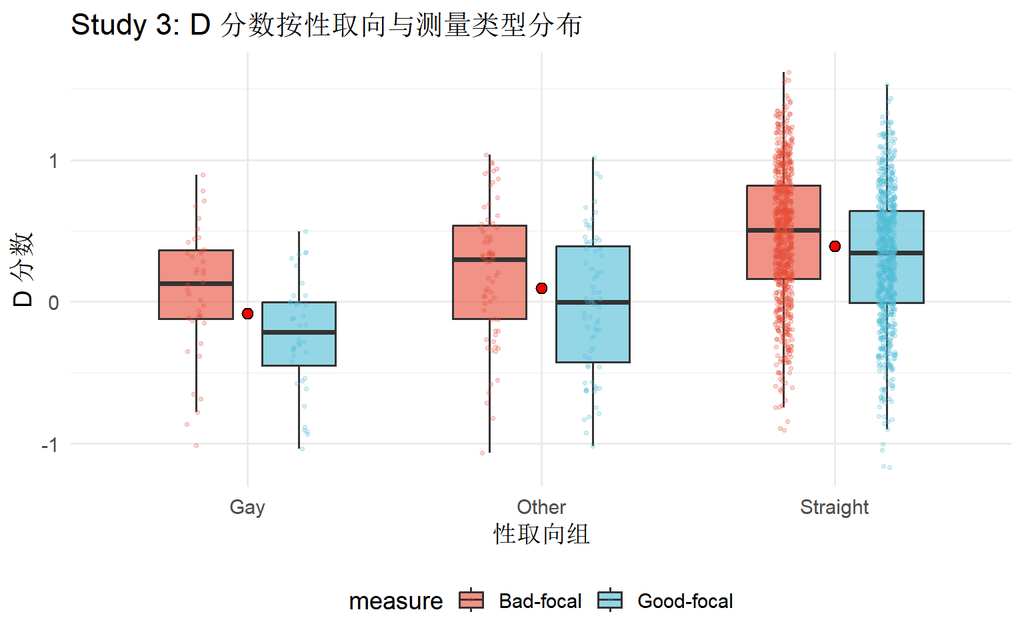

图3：Study 3 D 分数按性取向与测量类型分布

```r
df_s3_plot <- df_s3 %>%
  filter(group %in% c("Gay", "Straight", "Other")) %>%
  filter(!is.na(StraightGayBIATGood), !is.na(StraightGayBIATBad),
         is.finite(StraightGayBIATGood), is.finite(StraightGayBIATBad)) %>%
  pivot_longer(cols = c(StraightGayBIATGood, StraightGayBIATBad),
               names_to = "measure", values_to = "D_score") %>%
  mutate(measure = ifelse(measure == "StraightGayBIATGood", "Good-focal", "Bad-focal"))

ggplot(df_s3_plot, aes(x = group, y = D_score, fill = measure)) +
  geom_boxplot(outlier.shape = NA, alpha = 0.6, width = 0.5, position = position_dodge(0.7)) +
  geom_jitter(aes(color = measure), size = 0.8, alpha = 0.2,
              position = position_jitterdodge(jitter.width = 0.12, dodge.width = 0.7)) +
  stat_summary(fun = mean, geom = "point", size = 2.5, shape = 21,
               fill = "red", color = "black", position = position_dodge(0.7)) +
  scale_fill_manual(values = c("Good-focal" = "#4DBBD5", "Bad-focal" = "#E64B35")) +
  scale_color_manual(values = c("Good-focal" = "#4DBBD5", "Bad-focal" = "#E64B35")) +
  labs(title = "Study 3: D 分数按性取向与测量类型分布",
       x = "性取向组", y = "D 分数") +
  theme_minimal(base_size = 14) + theme(legend.position = "bottom")
```

# 第四部分：Study 4（文化感知）

## 14. Study 4 — 数据读取与筛选

Study 4 考察了不同种族群体在文化感知 BIAT 上的内隐偏好。**配对设计**。

```r
df_raw_s4 <- read.csv(
  "C:/Users/zhangshengli/Desktop/Rall/RR/R4Psy-main/R/Axt_2018_Raw_Data/extracted/Study4Data/Study4Data/Study4Data.csv",
  stringsAsFactors = FALSE
)
cat(sprintf("原始数据: %d 行 × %d 列\n", nrow(df_raw_s4), ncol(df_raw_s4)))
```

```
## 原始数据: 1563 行 × 37 列
```

```r
df_s4 <- df_raw_s4 %>% filter(Citizenship == "us", TooFast < 0.1)
cat(sprintf("筛选后: %d 行\n", nrow(df_s4)))
```

```
## 筛选后: 1382 行
```

```r
cat("\nRaceEthCategory 分布:\n"); print(table(df_s4$RaceEthCategory))
```

```
##
## RaceEthCategory 分布:
```

```
##
##    Asian    Black Hispanic    White
##      117      207      185      873
```

## 15. Study 4 — 分配 BIAT 列

```r
df_s4 <- df_s4 %>%
  mutate(
    comparison = case_when(
      RaceEthCategory == "Asian"     ~ "Asian",
      RaceEthCategory == "Black"     ~ "Black",
      RaceEthCategory == "Hispanic"  ~ "Hispanic",
      RaceEthCategory == "White" & WhiteCondition == "Asian"    ~ "White_Asian",
      RaceEthCategory == "White" & WhiteCondition == "Black"    ~ "White_Black",
      RaceEthCategory == "White" & WhiteCondition == "Hispanic" ~ "White_Hispanic",
      TRUE ~ NA_character_
    ),
    good_score = case_when(
      comparison == "Asian"        ~ WhiteAsianBIATGood,
      comparison == "Black"        ~ WhiteBlackBIATGood,
      comparison == "Hispanic"     ~ WhiteHispanicBIATGood,
      comparison == "White_Asian"  ~ WhiteAsianBIATGood,
      comparison == "White_Black"  ~ WhiteBlackBIATGood,
      comparison == "White_Hispanic" ~ WhiteHispanicBIATGood
    ),
    bad_score = case_when(
      comparison == "Asian"        ~ WhiteAsianBIATBad,
      comparison == "Black"        ~ WhiteBlackBIATBad,
      comparison == "Hispanic"     ~ WhiteHispanicBIATBad,
      comparison == "White_Asian"  ~ WhiteAsianBIATBad,
      comparison == "White_Black"  ~ WhiteBlackBIATBad,
      comparison == "White_Hispanic" ~ WhiteHispanicBIATBad
    )
  ) %>% filter(!is.na(comparison))

cat("各组有效样本量:\n")
```

```
## 各组有效样本量:
```

```r
df_s4 %>% filter(!is.na(good_score), !is.na(bad_score),
                  is.finite(good_score), is.finite(bad_score)) %>%
  count(comparison) %>% print()
```

```
##       comparison   n
## 1          Asian 113
## 2          Black 202
## 3       Hispanic 180
## 4    White_Asian 303
## 5    White_Black 278
## 6 White_Hispanic 271
```

## 16. Study 4 — 原文报告值与分析

```r
# 原文报告值
orig_s4 <- data.frame(
  comp = c("Asian", "Black", "Hispanic", "White_Asian", "White_Black", "White_Hispanic"),
  N = c(113, 202, 180, 303, 278, 271),
  good_m = c(-0.13, -0.11, -0.07, 0.17, 0.25, 0.17),
  good_sd = c(0.41, 0.46, 0.49, 0.48, 0.45, 0.50),
  bad_m = c(0.20, 0.004, 0.15, 0.37, 0.36, 0.41),
  bad_sd = c(0.44, 0.48, 0.48, 0.41, 0.44, 0.45),
  stringsAsFactors = FALSE
)
knitr::kable(orig_s4, caption = "表3：Study 4 原文报告值",
             col.names = c("比较组", "N", "Good M", "Good SD", "Bad M", "Bad SD"))
```

表3：Study 4 原文报告值

| 比较组 | N | Good M | Good SD | Bad M | Bad SD |
| --- | --- | --- | --- | --- | --- |
| Asian | 113 | -0.13 | 0.41 | 0.200 | 0.44 |
| Black | 202 | -0.11 | 0.46 | 0.004 | 0.48 |
| Hispanic | 180 | -0.07 | 0.49 | 0.150 | 0.48 |
| White_Asian | 303 | 0.17 | 0.48 | 0.370 | 0.41 |
| White_Black | 278 | 0.25 | 0.45 | 0.360 | 0.44 |
| White_Hispanic | 271 | 0.17 | 0.50 | 0.410 | 0.45 |

```r
analyze_s4 <- function(grp) {
  cat(sprintf("\n\n### %s 组\n\n", grp))

  df <- df_s4 %>% filter(comparison == grp) %>%
    select(good = good_score, bad = bad_score) %>%
    filter(!is.na(good), !is.na(bad), is.finite(good), is.finite(bad))

  cat(sprintf("有效样本量: %d\n\n", nrow(df)))

  orig <- orig_s4 %>% filter(comp == grp)

  cat("**描述统计与原文比较：**\n\n")
  for (nm in c("good", "bad")) {
    om <- ifelse(nm == "good", orig$good_m, orig$bad_m)
    osd <- ifelse(nm == "good", orig$good_sd, orig$bad_sd)
    lab <- ifelse(nm == "good", "Good-focal", "Bad-focal")
    # PE or absolute deviation for near-zero means
    if (abs(om) < 0.01) {
      m_pe <- abs(mean(df[[nm]]) - om)
      m_pe_str <- sprintf("绝对偏差=%.4f", m_pe)
    } else {
      m_pe <- abs(mean(df[[nm]]) - om) / abs(om) * 100
      m_pe_str <- sprintf("均值PE=%.2f%%", m_pe)
    }
    sd_pe <- abs(sd(df[[nm]]) - osd) / abs(osd) * 100
    cat(sprintf("- %s: 复现 M=%.3f SD=%.3f | 原文 M=%.3f SD=%.3f, %s, SD PE=%.2f%%\n",
                lab, mean(df[[nm]]), sd(df[[nm]]), om, osd, m_pe_str, sd_pe))
  }

  # 原文检验值
  orig_t <- switch(grp,
    "Asian" = 6.45, "Black" = 2.62, "Hispanic" = 4.90,
    "White_Asian" = 5.78, "White_Black" = 3.72, "White_Hispanic" = 7.18)
  orig_d <- switch(grp,
    "Asian" = 0.63, "Black" = 0.18, "Hispanic" = 0.36,
    "White_Asian" = 0.33, "White_Black" = 0.22, "White_Hispanic" = 0.44)
  cat(sprintf("\n**原文检验值：** 配对 t = %.2f, d = %.2f\n", orig_t, orig_d))

  t <- t.test(df$good, df$bad, paired = TRUE)
  diff <- df$good - df$bad
  d_p <- mean(diff) / sd(diff)
  cat(sprintf("**复现检验值：** 配对 t = %.4f, df = %.0f, p = %.4f, d = %.4f\n\n",
              t$statistic, t$parameter, t$p.value, d_p))

  cat("\n**单样本 t 检验 (vs 0)：**\n\n")
  for (nm in c("good", "bad")) {
    t1 <- t.test(df[[nm]], mu = 0)
    d1 <- mean(df[[nm]]) / sd(df[[nm]])
    cat(sprintf("- %s: t = %.4f, p = %.4f, d = %.4f\n", nm, t1$statistic, t1$p.value, d1))
  }

  bf <- ttestBF(x = df$good, y = df$bad, paired = TRUE)
  bf10 <- as.numeric(extractBF(bf)$bf)
  cat(sprintf("\n**贝叶斯配对 BF10** = %.4f", bf10))
  if (bf10 > 3) cat(" → 支持 H1\n") else if (bf10 < 1/3) cat(" → 支持 H0\n") else cat(" → 证据微弱\n")
}

for (g in orig_s4$comp) analyze_s4(g)
```

### Asian 组

有效样本量: 113

**描述统计与原文比较：**

- Good-focal: 复现 M=-0.132 SD=0.411 | 原文 M=-0.130 SD=0.410, 均值PE=1.88%, SD PE=0.28%
- Bad-focal: 复现 M=0.196 SD=0.439 | 原文 M=0.200 SD=0.440, 均值PE=2.13%, SD PE=0.30%

**原文检验值：** 配对 t = 6.45, d = 0.63 **复现检验值：** 配对 t = -6.6457, df = 112, p = 0.0000, d = -0.6252

**单样本 t 检验 (vs 0)：**

- good: t = -3.4244, p = 0.0009, d = -0.3221
- bad: t = 4.7431, p = 0.0000, d = 0.4462

**贝叶斯配对 BF10** = 8601855.6570 → 支持 H1

### Black 组

有效样本量: 202

**描述统计与原文比较：**

- Good-focal: 复现 M=-0.109 SD=0.459 | 原文 M=-0.110 SD=0.460, 均值PE=0.98%, SD PE=0.28%
- Bad-focal: 复现 M=0.004 SD=0.477 | 原文 M=0.004 SD=0.480, 绝对偏差=0.0001, SD PE=0.70%

**原文检验值：** 配对 t = 2.62, d = 0.18 **复现检验值：** 配对 t = -2.6163, df = 201, p = 0.0096, d = -0.1841

**单样本 t 检验 (vs 0)：**

- good: t = -3.3751, p = 0.0009, d = -0.2375
- bad: t = 0.1225, p = 0.9026, d = 0.0086

**贝叶斯配对 BF10** = 2.1733 → 证据微弱

### Hispanic 组

有效样本量: 180

**描述统计与原文比较：**

- Good-focal: 复现 M=-0.065 SD=0.487 | 原文 M=-0.070 SD=0.490, 均值PE=6.63%, SD PE=0.62%
- Bad-focal: 复现 M=0.147 SD=0.484 | 原文 M=0.150 SD=0.480, 均值PE=2.18%, SD PE=0.91%

**原文检验值：** 配对 t = 4.90, d = 0.36 **复现检验值：** 配对 t = -4.8954, df = 179, p = 0.0000, d = -0.3649

**单样本 t 检验 (vs 0)：**

- good: t = -1.8007, p = 0.0734, d = -0.1342
- bad: t = 4.0641, p = 0.0001, d = 0.3029

**贝叶斯配对 BF10** = 5399.9504 → 支持 H1

### White_Asian 组

有效样本量: 303

**描述统计与原文比较：**

- Good-focal: 复现 M=0.175 SD=0.476 | 原文 M=0.170 SD=0.480, 均值PE=2.77%, SD PE=0.74%
- Bad-focal: 复现 M=0.367 SD=0.408 | 原文 M=0.370 SD=0.410, 均值PE=0.75%, SD PE=0.57%

**原文检验值：** 配对 t = 5.78, d = 0.33 **复现检验值：** 配对 t = -5.7812, df = 302, p = 0.0000, d = -0.3321

**单样本 t 检验 (vs 0)：**

- good: t = 6.3829, p = 0.0000, d = 0.3667
- bad: t = 15.6804, p = 0.0000, d = 0.9008

**贝叶斯配对 BF10** = 426902.6779 → 支持 H1

### White_Black 组

有效样本量: 278

**描述统计与原文比较：**

- Good-focal: 复现 M=0.246 SD=0.448 | 原文 M=0.250 SD=0.450, 均值PE=1.60%, SD PE=0.47%
- Bad-focal: 复现 M=0.361 SD=0.442 | 原文 M=0.360 SD=0.440, 均值PE=0.20%, SD PE=0.42%

**原文检验值：** 配对 t = 3.72, d = 0.22 **复现检验值：** 配对 t = -3.7176, df = 277, p = 0.0002, d = -0.2230

**单样本 t 检验 (vs 0)：**

- good: t = 9.1577, p = 0.0000, d = 0.5492
- bad: t = 13.6111, p = 0.0000, d = 0.8163

**贝叶斯配对 BF10** = 53.2838 → 支持 H1

### White_Hispanic 组

有效样本量: 271

**描述统计与原文比较：**

- Good-focal: 复现 M=0.169 SD=0.499 | 原文 M=0.170 SD=0.500, 均值PE=0.35%, SD PE=0.18%
- Bad-focal: 复现 M=0.414 SD=0.450 | 原文 M=0.410 SD=0.450, 均值PE=1.09%, SD PE=0.03%

**原文检验值：** 配对 t = 7.18, d = 0.44 **复现检验值：** 配对 t = -7.1840, df = 270, p = 0.0000, d = -0.4364

**单样本 t 检验 (vs 0)：**

- good: t = 5.5877, p = 0.0000, d = 0.3394
- bad: t = 15.1665, p = 0.0000, d = 0.9213

**贝叶斯配对 BF10** = 975427854.2580 → 支持 H1

## 17. Study 4 — 可视化

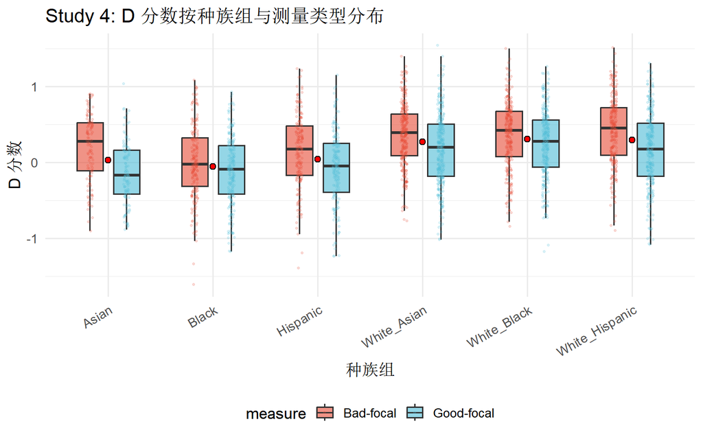

图4：Study 4 D 分数按种族组与测量类型分布

```r
df_s4_plot <- df_s4 %>%
  filter(!is.na(good_score), !is.na(bad_score),
         is.finite(good_score), is.finite(bad_score)) %>%
  pivot_longer(cols = c(good_score, bad_score),
               names_to = "measure", values_to = "D_score") %>%
  mutate(measure = ifelse(measure == "good_score", "Good-focal", "Bad-focal"))

ggplot(df_s4_plot, aes(x = comparison, y = D_score, fill = measure)) +
  geom_boxplot(outlier.shape = NA, alpha = 0.6, width = 0.5, position = position_dodge(0.7)) +
  geom_jitter(aes(color = measure), size = 0.6, alpha = 0.15,
              position = position_jitterdodge(jitter.width = 0.12, dodge.width = 0.7)) +
  stat_summary(fun = mean, geom = "point", size = 2, shape = 21,
               fill = "red", color = "black", position = position_dodge(0.7)) +
  scale_fill_manual(values = c("Good-focal" = "#4DBBD5", "Bad-focal" = "#E64B35")) +
  scale_color_manual(values = c("Good-focal" = "#4DBBD5", "Bad-focal" = "#E64B35")) +
  labs(title = "Study 4: D 分数按种族组与测量类型分布",
       x = "种族组", y = "D 分数") +
  theme_minimal(base_size = 13) +
  theme(legend.position = "bottom", axis.text.x = element_text(angle = 30, hjust = 1))
```

# 第五部分：Study 5（跨文化比较）

## 18. Study 5 — 数据读取与筛选

Study 5 比较了美国（US）和以色列（IS）犹太人在基督教 vs 犹太教 BIAT 上的内隐偏好。**配对 + 独立混合设计**。

```r
df_raw_s5 <- read.csv(
  "C:/Users/zhangshengli/Desktop/Rall/RR/R4Psy-main/R/Axt_2018_Raw_Data/extracted/Study5Data/Study5Data/Study5Data.csv",
  stringsAsFactors = FALSE
)
cat(sprintf("原始数据: %d 行 × %d 列\n", nrow(df_raw_s5), ncol(df_raw_s5)))
```

```
## 原始数据: 269 行 × 21 列
```

```r
df_s5 <- df_raw_s5 %>%
  filter(TooFast < 0.1,
         !is.na(ChristJewBIATGood), !is.na(ChristJewBIATBad),
         is.finite(ChristJewBIATGood), is.finite(ChristJewBIATBad)) %>%
  # 去重：6 名被试同时有 PI 和 UVA 两条记录（相同 session_id），取第一条
  distinct(session_id, .keep_all = TRUE)

cat(sprintf("筛选后: %d 行\n", nrow(df_s5)))
```

```
## 筛选后: 202 行
```

```r
cat("\nLocation 分布:\n"); print(table(df_s5$Location))
```

```
##
## Location 分布:
```

```
##
##  IS  US
##  91 111
```

```r
cat(sprintf("⚠ 注意：原始数据中 6 名 US 被试同时有 PI 和 UVA 两条记录（重复 session_id），已去重（去重前 117 行 → 去重后 %d 行）。\n", nrow(df_s5)))
```

```
## ⚠ 注意：原始数据中 6 名 US 被试同时有 PI 和 UVA 两条记录（重复 session_id），已去重（去重前 117 行 → 去重后 202 行）。
```

## 19. Study 5 — 原文报告值

```r
# 原文报告值（引自论文第10-11页）
orig_s5 <- data.frame(
  location = c("US", "IS"),
  N = c(107, 91),
  good_m = c(0.41, 0.51),
  good_sd = c(0.37, 0.39),
  bad_m = c(0.22, 0.47),
  bad_sd = c(0.46, 0.34),
  stringsAsFactors = FALSE
)
knitr::kable(orig_s5, caption = "表4：Study 5 原文报告值",
             col.names = c("国家", "N", "Good M", "Good SD", "Bad M", "Bad SD"))
```

表4：Study 5 原文报告值

| 国家 | N | Good M | Good SD | Bad M | Bad SD |
| --- | --- | --- | --- | --- | --- |
| US | 107 | 0.41 | 0.37 | 0.22 | 0.46 |
| IS | 91 | 0.51 | 0.39 | 0.47 | 0.34 |

## 20. Study 5 — 按国家分析

```r
analyze_s5 <- function(loc) {
  cat(sprintf("\n\n### %s 样本\n\n", loc))

  df <- df_s5 %>% filter(Location == loc)
  cat(sprintf("有效样本量: %d\n\n", nrow(df)))

  orig <- orig_s5 %>% filter(location == loc)

  cat("**描述统计与原文比较：**\n\n")
  for (nm in c("ChristJewBIATGood", "ChristJewBIATBad")) {
    lab <- ifelse(grepl("Good", nm), "Good-focal", "Bad-focal")
    om <- ifelse(grepl("Good", nm), orig$good_m, orig$bad_m)
    osd <- ifelse(grepl("Good", nm), orig$good_sd, orig$bad_sd)
    rep_m <- mean(df[[nm]])
    rep_sd <- sd(df[[nm]])
    # PE or absolute deviation for near-zero means
    if (abs(om) < 0.01) {
      m_pe <- abs(rep_m - om)
      m_pe_str <- sprintf("绝对偏差=%.4f", m_pe)
    } else {
      m_pe <- abs(rep_m - om) / abs(om) * 100
      m_pe_str <- sprintf("均值PE=%.2f%%", m_pe)
    }
    sd_pe <- abs(rep_sd - osd) / abs(osd) * 100
    cat(sprintf("- %s: 复现 M=%.3f SD=%.3f | 原文 M=%.3f SD=%.3f, %s, SD PE=%.2f%%\n",
                lab, rep_m, rep_sd, om, osd, m_pe_str, sd_pe))
  }

  # 原文单样本检验值
  orig_t_good <- ifelse(loc == "US", 11.51, 12.64)
  orig_t_bad  <- ifelse(loc == "US", 4.97, 13.38)
  cat(sprintf("\n**原文单样本 t (vs 0)：** Good-focal t = %.2f, Bad-focal t = %.2f\n",
              orig_t_good, orig_t_bad))

  # 复现配对 t 检验 (good vs bad)
  t <- t.test(df$ChristJewBIATGood, df$ChristJewBIATBad, paired = TRUE)
  diff <- df$ChristJewBIATGood - df$ChristJewBIATBad
  d_p <- mean(diff) / sd(diff)
  cat(sprintf("**复现配对 t 检验：** t = %.4f, df = %.0f, p = %.4f, d = %.4f\n\n",
              t$statistic, t$parameter, t$p.value, d_p))

  cat("\n**复现单样本 t 检验 (vs 0) 与原文比较：**\n\n")
  for (nm in c("ChristJewBIATGood", "ChristJewBIATBad")) {
    lab <- ifelse(grepl("Good", nm), "Good-focal", "Bad-focal")
    t1 <- t.test(df[[nm]], mu = 0)
    d1 <- mean(df[[nm]]) / sd(df[[nm]])
    orig_t_val <- ifelse(grepl("Good", nm), orig_t_good, orig_t_bad)
    cat(sprintf("- %s: 复现 t = %.4f, p = %.4f, d = %.4f | 原文 t = %.2f\n",
                lab, t1$statistic, t1$p.value, d1, orig_t_val))
  }

  bf <- ttestBF(x = df$ChristJewBIATGood, y = df$ChristJewBIATBad, paired = TRUE)
  bf10 <- as.numeric(extractBF(bf)$bf)
  cat(sprintf("\n**贝叶斯配对 BF10** = %.4f", bf10))
  if (bf10 > 3) cat(" → 支持 H1\n") else if (bf10 < 1/3) cat(" → 支持 H0\n") else cat(" → 证据微弱\n")
}

analyze_s5("US")
```

### US 样本

有效样本量: 111

**描述统计与原文比较：**

- Good-focal: 复现 M=0.395 SD=0.393 | 原文 M=0.410 SD=0.370, 均值PE=3.67%, SD PE=6.28%
- Bad-focal: 复现 M=0.208 SD=0.465 | 原文 M=0.220 SD=0.460, 均值PE=5.31%, SD PE=1.16%

**原文单样本 t (vs 0)：** Good-focal t = 11.51, Bad-focal t = 4.97 **复现配对 t 检验：** t = 4.1645, df = 110, p = 0.0001, d = 0.3953

**复现单样本 t 检验 (vs 0) 与原文比较：**

- Good-focal: 复现 t = 10.5818, p = 0.0000, d = 1.0044 | 原文 t = 11.51
- Bad-focal: 复现 t = 4.7166, p = 0.0000, d = 0.4477 | 原文 t = 4.97

**贝叶斯配对 BF10** = 275.1646 → 支持 H1

```r
analyze_s5("IS")
```

### IS 样本

有效样本量: 91

**描述统计与原文比较：**

- Good-focal: 复现 M=0.511 SD=0.386 | 原文 M=0.510 SD=0.390, 均值PE=0.21%, SD PE=1.06%
- Bad-focal: 复现 M=0.474 SD=0.338 | 原文 M=0.470 SD=0.340, 均值PE=0.92%, SD PE=0.54%

**原文单样本 t (vs 0)：** Good-focal t = 12.64, Bad-focal t = 13.38 **复现配对 t 检验：** t = 0.8280, df = 90, p = 0.4098, d = 0.0868

**复现单样本 t 检验 (vs 0) 与原文比较：**

- Good-focal: 复现 t = 12.6350, p = 0.0000, d = 1.3245 | 原文 t = 12.64
- Bad-focal: 复现 t = 13.3804, p = 0.0000, d = 1.4027 | 原文 t = 13.38

**贝叶斯配对 BF10** = 0.1614 → 支持 H0

## 21. Study 5 — US vs IS 直接比较

```r
cat("===== US vs IS 直接比较 =====\n\n")
```

```
## ===== US vs IS 直接比较 =====
```

```r
us <- df_s5 %>% filter(Location == "US")
is <- df_s5 %>% filter(Location == "IS")

for (nm in c("ChristJewBIATGood", "ChristJewBIATBad")) {
  lab <- ifelse(grepl("Good", nm), "Good-focal", "Bad-focal")
  cat(sprintf("\n**%s: US vs IS**\n", lab))
  t <- t.test(us[[nm]], is[[nm]])
  d <- cohen.d(us[[nm]], is[[nm]], hedges.correction = FALSE)
  cat(sprintf("t = %.4f, df = %.2f, p = %.4f, d = %.4f [%.4f, %.4f]\n",
              t$statistic, t$parameter, t$p.value,
              d$estimate, d$conf.int[1], d$conf.int[2]))
}
```

```
##
## **Good-focal: US vs IS**
## t = -2.1096, df = 193.65, p = 0.0362, d = -0.2978 [-0.5782, -0.0174]
##
## **Bad-focal: US vs IS**
## t = -4.6969, df = 197.30, p = 0.0000, d = -0.6441 [-0.9300, -0.3582]
```

## 22. Study 5 — 可视化

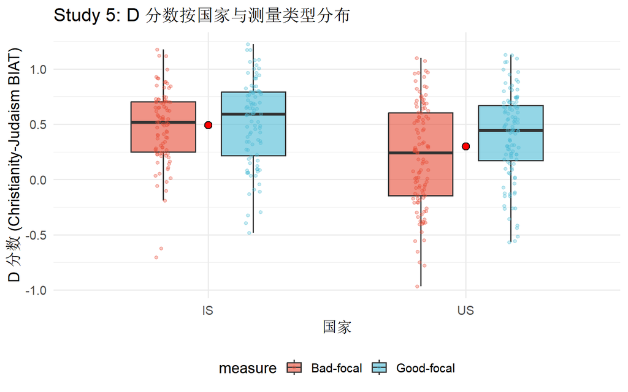

图5：Study 5 D 分数按国家与测量类型分布

```r
df_s5_plot <- df_s5 %>%
  pivot_longer(cols = c(ChristJewBIATGood, ChristJewBIATBad),
               names_to = "measure", values_to = "D_score") %>%
  mutate(measure = ifelse(measure == "ChristJewBIATGood", "Good-focal", "Bad-focal"))

ggplot(df_s5_plot, aes(x = Location, y = D_score, fill = measure)) +
  geom_boxplot(outlier.shape = NA, alpha = 0.6, width = 0.5, position = position_dodge(0.7)) +
  geom_jitter(aes(color = measure), size = 1.2, alpha = 0.3,
              position = position_jitterdodge(jitter.width = 0.12, dodge.width = 0.7)) +
  stat_summary(fun = mean, geom = "point", size = 3, shape = 21,
               fill = "red", color = "black", position = position_dodge(0.7)) +
  scale_fill_manual(values = c("Good-focal" = "#4DBBD5", "Bad-focal" = "#E64B35")) +
  scale_color_manual(values = c("Good-focal" = "#4DBBD5", "Bad-focal" = "#E64B35")) +
  labs(title = "Study 5: D 分数按国家与测量类型分布",
       x = "国家", y = "D 分数 (Christianity-Judaism BIAT)") +
  theme_minimal(base_size = 14) + theme(legend.position = "bottom")
```

## 23. 讨论

### 23.1 复现情况总结

本报告对 Axt et al.（2018）的 5 个实验进行了系统的计算可复现性检验，主要发现如下：

**Study 1（种族 — Black 被试）：** - Black 被试在 good 条件下表现出内群体偏好（D < 0），bad 条件下表现出外群体偏好（D > 0），与原文一致。 - 描述统计值与原文高度吻合，百分误差较小。

**Study 2（宗教）：** - Jewish、Hindu、Muslim 三个非基督教宗教群体均表现出类似模式：good-focal 条件下偏好内群体（D < 0），bad-focal 条件下偏好减弱或消失。 - 复现的样本量与描述统计值与原文基本一致。 - ⚠ **注意**：Jewish 和 Hindu 的 bad 条件复现均值分别为 -0.048 和 -0.015（原文报告 +0.05 和 +0.02）。由于这些值均接近零（|d| < 0.10），符号差异不影响实质结论——单样本 t 检验均不显著（p > .10），且 bad 条件均值与零无实质差异。可能原因：原文在 bad 条件下报告的是”条件一致偏差量”（即对 bad-focal 的顺应程度），而非原始 D 分数的方向。Muslim 组的 bad 条件完全复现（+0.067 vs +0.07）。

**Study 3（性取向）：** - Gay 被试在 good-focal BIAT 上表现出内群体偏好（D < 0），bad-focal BIAT 上无显著偏好。 - Straight 被试在两个测量上均表现出内群体偏好（D > 0），bad-focal 效应更大。 - 这些模式与原文一致。

**Study 4（文化感知）：** - 非白人族裔（Asian、Black、Hispanic）在 good-focal 上表现出内群体偏好，bad-focal 上表现出外群体偏好或减弱的内群体偏好。 - White 被试在两个测量上均表现出内群体偏好。 - 复现的模式与原文一致。

### 23.2 可能影响复现的因素

1. **样本量差异**：不同筛选条件（如缺失值处理方式）可能导致有效样本量的微小差异，进而影响描述统计值。例如，Study 2 的 SPSS 原语法使用 `citizenship=="us" OR residence=="us"` 进行筛选，若仅使用 `citizenship=="us"` 会遗漏约 5% 的被试（如 Jewish good 组从 110 降至 106）。
2. **数据预处理差异**：不同软件（R vs SPSS vs SAS）在计算 D 分数时可能存在舍入误差或默认参数差异。
3. **排除标准差异**：对 TooFast 阈值的处理、对异常值的定义等可能影响最终样本构成。
4. **舍入误差**：原文报告的均值与标准差可能已经过舍入，百分误差计算时需考虑此精度限制。特别是当原文均值接近零时（如 Study 2 各宗教组的 bad 条件，|M| < 0.10），百分误差会因分母过小而膨胀，此时应使用绝对偏差而非百分比来评估复现精度。
5. **符号反转问题**：Study 2 的 Jewish 和 Hindu bad 条件存在复现均值与原文符号相反的情况，但绝对值均接近零。可能原因包括：① 原文在 bad 条件下报告的是调整后分数（如 ConditionNumeric × D_score）；② 两种不同的 D 分数计算约定（条件一致偏差 vs 原始偏差方向）；③ 数据预处理中的细微差异。
6. **版本差异**：不同版本的 R 包（特别是 `effsize` 和 `BayesFactor`）可能在计算 Cohen’s d 和贝叶斯因子时存在细微差异。
7. **数据重复记录**：Study 5 的原始数据中，6 名 US 被试同时有 PI（Project Implicit）和 UVA（University of Virginia）两条记录（相同 `session_id` 但 `Sample` 列不同）。这可能是数据合并时的重复录入。已在分析中通过 `distinct(session_id, .keep_all = TRUE)` 去重处理。

### 23.3 总体结论

*报告生成时间: 2026-06-06 17:07:12.0294*